# ADSP 31013 IP01 Big Data and Cloud Computing

## Group Project – NYC Yellow Taxi Trips (2024/01/01 – 2025/10/15)

### NYC Yellow Taxi Trips – **Fare Prediction (Regression) Model Training**

This notebook presents the **regression model development pipeline** for **Group 8** in **ADSP 31013 Big Data and Cloud Computing**. Building on the earlier EDA work, this notebook focuses exclusively on constructing, training, evaluating, and tuning machine-learning models for **fare prediction** using **PySpark MLlib** on a multi-million-row dataset of NYC Yellow Taxi trips enriched with hourly weather data.

**Business Context**

Fare prediction plays a central role in urban transportation analytics. NYC Yellow Taxi operators, transportation planners, and mobility service platforms rely on accurate fare estimates to:

- Improve **revenue forecasting** under varying demand and weather conditions
- Support **fare transparency** and consistency across vendors
- Identify anomalous or fraudulent trips through **outlier detection**
- Understand how external factors—such as weather, congestion, or location—affect trip pricing

As the dataset spans diverse boroughs, weather patterns, and trip contexts, building an explainable and scalable regression model provides operational insights and supports downstream applications in taxi pricing and mobility planning.

**Business Problem – Fare Prediction**

The primary objective of this notebook is to model:

**Predicting `Fare` Based on Trip & Environmental Features**

Given historical taxi trip records, the model aims to estimate the **fare charged** to a passenger, capturing key drivers such as:

- Trip distance & duration
- Pickup and dropoff locations (borough/zone encodings)
- Passenger count, vendor metadata, and rate codes
- Weather conditions at the time of pickup and dropoff

This supports several stakeholders:

- **Drivers / Operators** — more accurate expectations of revenue per trip
- **Regulators** — transparency for pricing and anomaly detection
- **Passengers** — ability to forecast likely cost given trip context
- **Policy Analysts** — understanding cost dynamics influenced by weather and congestion

**Modeling Approach (PySpark MLlib)**

This notebook develops an end-to-end regression pipeline using **PySpark MLlib**, including:

**Feature Engineering**

**Regression Models Used**

**Training & Evaluation**

- Train/validation split for performance measurement
- Metrics:
  - **RMSE** (primary metric)
  - **MAE**
  - **R²**
- Residual diagnostics and feature contribution analysis (where applicable)

**Hyperparameter Tuning**

- Grid search via `TrainValidationSplit` or `CrossValidator`
- Tuning learning rate, tree depth, number of estimators, regularization, etc.

**Scalable Model Training**

All training is executed using Spark’s distributed computation on data stored in our group’s **GCS bucket** (`msca-bdp-student-gcs/group_8_project`), demonstrating big-data ML workflows.

**Key Variables**

**Response Variable**

- **`fare_amount`** — Fare (base fare on the meter) charged to the passenger

**Explanatory Variables**

**Trip Characteristics**

- `trip_distance`
- `passenger_count`
- `ratecode_id`, `vendor_id`, `payment_type`
- Pickup/dropoff zone & borough encodings
- Derived `trip_duration`

**Weather Features (Pickup & Dropoff)**

These variables capture both structural pricing components and external environmental factors influencing trip cost.

This notebook constructs the full regression modeling workflow—from preprocessing to model tuning and evaluation—establishing the foundation for scalable fare prediction under the NYC Yellow Taxi dataset.

**Author(s):** Zihao Huang (zihaoh3@uchicago.edu), Ray Gong (ruigong1307@uchicago.edu), Leo Liu (jliu888@uchicago.edu), Wade Chen (wangdi@uchicago.edu), Tom Chen (cychen1@uchicago.edu)

### **0. Environment Setup and Spark Session**

The first step in this notebook is to import all required PySpark components and initialize the Spark environment. We load the core MLlib utilities—including feature transformers, regression models, evaluators, and pipeline classes—that will be used throughout the model development workflow.

```python
from pyspark.sql import SparkSession

from pyspark.sql import functions as F
from pyspark.sql.types import FloatType

from pyspark.ml import Pipeline, Transformer
from pyspark.ml.util import DefaultParamsReadable, DefaultParamsWritable

from pyspark.ml.feature import StringIndexer, OneHotEncoder, IndexToString, VectorAssembler

from pyspark.ml.regression import LinearRegression, RandomForestRegressor, RandomForestRegressionModel


from pyspark.ml.evaluation import RegressionEvaluator

from pyspark.ml.tuning import CrossValidator, ParamGridBuilder

import matplotlib.pyplot as plt
```

```python
from IPython.core.display import HTML
display(HTML("<style>pre { white-space: pre !important; }</style>"))
```

After importing dependencies, we create a SparkSession named “NYC-Yellow-Taxi-Fare-Prediction”, which serves as the main entry point for distributed DataFrame operations and MLlib pipelines. All subsequent data loading, feature engineering, model training, and evaluation will be executed using this Spark session.

```python
spark = SparkSession.builder.appName("NYC-Yellow-Taxi-Fare-Prediction").getOrCreate()
```

```python
spark.sparkContext.getConf().getAll()
```

[output not shown]

[output cut: 31 more lines]

[output not shown]

### **1. Data Loading & Basic Sanity Checks**

In this step, we load the cleaned and joined NYC Yellow Taxi + Weather dataset from our group’s GCS bucket. The data has been preprocessed and stored in Parquet format, which offers efficient columnar compression and faster loading compared to CSV—an important advantage given the dataset’s large size (≈58.9 million rows).

We begin by reading the Parquet files into a Spark DataFrame and inspecting the schema to confirm that all trip, weather, and fare-related fields have been correctly preserved from the data-cleaning pipeline.

```python
bucket_url = "gs://msca-bdp-student-gcs/group_8_project/datasets/"

df = spark.read.parquet(bucket_url + "cleaned/parquet/")
```

```python
df.printSchema()
```

```
root
 |-- tpep_pickup_datetime: timestamp (nullable = true)
 |-- tpep_dropoff_datetime: timestamp (nullable = true)
 |-- pu_location_id: integer (nullable = true)
 |-- do_location_id: integer (nullable = true)
 |-- pu_borough: string (nullable = true)
 |-- pu_zone: string (nullable = true)
 |-- do_borough: string (nullable = true)
 |-- do_zone: string (nullable = true)
 |-- vendor_id: integer (nullable = true)
 |-- ratecode_id: integer (nullable = true)
 |-- passenger_count: integer (nullable = true)
 |-- trip_distance: double (nullable = true)
 |-- store_and_fwd_flag: string (nullable = true)
 |-- payment_type: integer (nullable = true)
 |-- fare_amount: double (nullable = true)
 |-- extra: double (nullable = true)
 |-- mta_tax: double (nullable = true)
 |-- tip_amount: double (nullable = true)
 |-- tolls_amount: double (nullable = true)
 |-- improvement_surcharge: double (nullable = true)
 |-- congestion_surcharge: double (nullable = true)
 |-- airport_fee: double (nullable = true)
 |-- total_amount: double (nullable = true)
 |-- pu_temp: double (nullable = true)
 |-- pu_dwpt: double (nullable = true)
 |-- pu_rhum: double (nullable = true)
 |-- pu_prcp: double (nullable = true)
 |-- pu_wdir: double (nullable = true)
 |-- pu_wspd: double (nullable = true)
 |-- pu_pres: double (nullable = true)
 |-- pu_coco: double (nullable = true)
 |-- do_temp: double (nullable = true)
 |-- do_dwpt: double (nullable = true)
 |-- do_rhum: double (nullable = true)
 |-- do_prcp: double (nullable = true)
 |-- do_wdir: double (nullable = true)
 |-- do_wspd: double (nullable = true)
 |-- do_pres: double (nullable = true)
 |-- do_coco: double (nullable = true)
 |-- trip_seconds: long (nullable = true)
 |-- tip_rate: double (nullable = true)
```

The schema inspection verifies the presence of timestamp fields, categorical IDs, continuous trip metrics, and pickup/dropoff weather attributes. A preview of several sample rows provides a quick qualitative sanity check for data correctness, ensuring values such as timestamps, distances, surcharges, and weather features align with expected ranges.

```python
df.show(5, truncate=False)
```

```
25/12/04 00:45:02 WARN org.apache.spark.sql.catalyst.util.package: Truncated the string representation of a plan since it was too large. This behavior can be adjusted by setting 'spark.sql.debug.maxToStringFields'.
[Stage 1:>                                                          (0 + 1) / 1]
```

```
+--------------------+---------------------+--------------+--------------+----------+--------------+----------+-------------------+---------+-----------+---------------+-------------+------------------+------------+-----------+-----+-------+----------+------------+---------------------+-------------…
|tpep_pickup_datetime|tpep_dropoff_datetime|pu_location_id|do_location_id|pu_borough|pu_zone       |do_borough|do_zone            |vendor_id|ratecode_id|passenger_count|trip_distance|store_and_fwd_flag|payment_type|fare_amount|extra|mta_tax|tip_amount|tolls_amount|improvement_surcharge|congestion_su…
+--------------------+---------------------+--------------+--------------+----------+--------------+----------+-------------------+---------+-----------+---------------+-------------+------------------+------------+-----------+-----+-------+----------+------------+---------------------+-------------…
|2024-03-09 11:23:38 |2024-03-09 11:43:42  |137           |144           |Manhattan |Kips Bay      |Manhattan |Little Italy/NoLiTa|2        |1          |1              |2.43         |N                 |1           |19.1       |0.0  |0.5    |4.62      |0.0         |1.0                  |2.5          …
|2024-07-10 12:10:48 |2024-07-10 12:54:29  |132           |170           |Queens    |JFK Airport   |Manhattan |Murray Hill        |2        |2          |1              |16.73        |N                 |1           |70.0       |0.0  |0.5    |16.19     |6.94        |1.0                  |2.5          …
|2024-04-15 18:44:09 |2024-04-15 19:02:25  |161           |143           |Manhattan |Midtown Center|Manhattan |Lincoln Square West|2        |1          |1              |2.41         |N                 |1           |17.7       |2.5  |0.5    |4.84      |0.0         |1.0                  |2.5          …
|2024-05-04 11:54:38 |2024-05-04 11:57:39  |43            |142           |Manhattan |Central Park  |Manhattan |Lincoln Square East|2        |1          |1              |0.54         |N                 |1           |5.1        |0.0  |0.5    |1.82      |0.0         |1.0                  |2.5          …
|2025-01-08 23:31:44 |2025-01-08 23:47:35  |163           |262           |Manhattan |Midtown North |Manhattan |Yorkville East     |2        |1          |1              |2.85         |N                 |1           |17.7       |1.0  |0.5    |4.69      |0.0         |1.0                  |2.5          …
+--------------------+---------------------+--------------+--------------+----------+--------------+----------+-------------------+---------+-----------+---------------+-------------+------------------+------------+-----------+-----+-------+----------+------------+---------------------+-------------…
only showing top 5 rows
```

```python
df.count()
```

```
58866036
```

```python
n = df.count()

(
    df
    .select([((F.count(F.when(df[c].isNull(), c))) / n).alias(c + "_missing_rate") for c in df.columns])
).show(vertical=True, truncate=False)
```

```
[Stage 13:=============================================>          (26 + 6) / 32]
```

```
-RECORD 0---------------------------------
 tpep_pickup_datetime_missing_rate  | 0.0
 tpep_dropoff_datetime_missing_rate | 0.0
 pu_location_id_missing_rate        | 0.0
 do_location_id_missing_rate        | 0.0
 pu_borough_missing_rate            | 0.0
 pu_zone_missing_rate               | 0.0
 do_borough_missing_rate            | 0.0
 do_zone_missing_rate               | 0.0
 vendor_id_missing_rate             | 0.0
 ratecode_id_missing_rate           | 0.0
 passenger_count_missing_rate       | 0.0
 trip_distance_missing_rate         | 0.0
 store_and_fwd_flag_missing_rate    | 0.0
 payment_type_missing_rate          | 0.0
 fare_amount_missing_rate           | 0.0
 extra_missing_rate                 | 0.0
 mta_tax_missing_rate               | 0.0
 tip_amount_missing_rate            | 0.0
 tolls_amount_missing_rate          | 0.0
 improvement_surcharge_missing_rate | 0.0
 congestion_surcharge_missing_rate  | 0.0
 airport_fee_missing_rate           | 0.0
 total_amount_missing_rate          | 0.0
 pu_temp_missing_rate               | 0.0
 pu_dwpt_missing_rate               | 0.0
 pu_rhum_missing_rate               | 0.0
 pu_prcp_missing_rate               | 0.0
 pu_wdir_missing_rate               | 0.0
 pu_wspd_missing_rate               | 0.0
 pu_pres_missing_rate               | 0.0
 pu_coco_missing_rate               | 0.0
 do_temp_missing_rate               | 0.0
 do_dwpt_missing_rate               | 0.0
 do_rhum_missing_rate               | 0.0
 do_prcp_missing_rate               | 0.0
 do_wdir_missing_rate               | 0.0
 do_wspd_missing_rate               | 0.0
 do_pres_missing_rate               | 0.0
 do_coco_missing_rate               | 0.0
 trip_seconds_missing_rate          | 0.0
 tip_rate_missing_rate              | 0.0
```

### **2. Define Prediction Target & Select Modeling Columns**

In this step, we formally define **`fare_amount`** as the regression target for our fare prediction model. Since `fare_amount` represents the **base meter fare**, we exclude all downstream billing components—such as taxes, surcharges, tolls, airport fees, and tips—from the feature set. Including these billing components would introduce label leakage and artificially inflate model performance, as many of these fields are deterministic add-ons to the base fare or behavioral outcomes (e.g., tip amount).

We construct a clean list of modeling features by removing:

- **Leakage fields:** `total_amount`, `tip_amount`, `tip_rate`
- **Billing components:** `extra`, `mta_tax`, `tolls_amount`, `improvement_surcharge`, `congestion_surcharge`, `airport_fee`

This prepares a clean modeling DataFrame that avoids leakage, ensures valid feature engineering, and maintains alignment with the real-world business problem.

```python
target = "fare_amount"

leakage_cols = [
    "total_amount",
    "tip_amount",
    "tip_rate",
]

billing_component_cols = [
    "extra",
    "mta_tax",
    "tolls_amount",
    "improvement_surcharge",
    "congestion_surcharge",
    "airport_fee",
]
```

**Refining Feature Set: Removing Time Columns and Redundant Location Fields**

After these refinements, the remaining feature set contains:

This yields a cleaner, less redundant feature matrix that is easier to interpret and more efficient for model training.

```python
time_cols = [
    "tpep_pickup_datetime",
    "tpep_dropoff_datetime",
]

redundant_location_cols = [
    "pu_location_id",
    "do_location_id"
]

weather_cols = [
    "temp", "dwpt", "rhum", "prcp", "wdir", "wspd", "pres", "coco"
]
```

### **3. Feature Selection & Engineering**

#### **3.1 Weather Feature Binning**

We first transform the raw pickup and dropoff weather measurements from Meteostat into semantically meaningful categorical buckets. For each of the pickup (`pu_*`) and dropoff (`do_*`) weather variables, we define custom bucketing functions:

- **Temperature (`*_temp`)** is grouped into `freezing`, `cold`, `cool`, `warm`, and `hot` based on °C ranges.
- **Dew point (`*_dwpt`)** is mapped to comfort-oriented categories such as `very_dry_cold`, `dry`, `comfortable`, `humid`, and `oppressive`.
- **Relative humidity (`*_rhum`)** is summarized as `dry`, `comfortable`, `humid`, or `very_humid`.
- **Precipitation (`*_prcp`)** (mm/hour) is categorized into `none`, `trace`, `light`, `moderate`, and `heavy`.
- **Wind direction (`*_wdir`)** is converted into 8 cardinal sectors: `N`, `NE`, `E`, `SE`, `S`, `SW`, `W`, `NW`.
- **Wind speed (`*_wspd`)** is grouped into `calm`, `light`, `moderate`, `fresh`, and `strong_gale`.
- **Pressure (`*_pres`)** is binned into `low`, `normal`, and `high`.
- **Weather condition code (`*_coco`)** is collapsed into broader classes such as `clear_fair`, `cloudy_overcast`, `fog`, `rain`, `freezing_rain`, `mixed_precip`, `snow`, `thunderstorm`, and `hail`.

These bucketed features (e.g., `pu_temp_bin`, `pu_prcp_bin`, `do_coco_bin`, etc.) capture interpretable weather regimes (like “warm & humid” or “heavy rain”) which can be more robust and easier to explain than the raw continuous values. After the bucketization, we drop the original numeric weather columns and keep only the binned versions for downstream modeling.

```python
def bucket_temp(col):
    """Temperature in °C: freezing, cold, cool, warm, hot."""
    return (
        F.when(col.isNull(), None)
         .when(col < 0, "freezing")
         .when(col < 10, "cold")
         .when(col < 20, "cool")
         .when(col < 30, "warm")
         .otherwise("hot")
    )

def bucket_dwpt(col):
    """Dew point in °C: comfort-oriented bins."""
    return (
        F.when(col.isNull(), None)
         .when(col <= 0, "very_dry_cold")
         .when(col < 10, "dry")
         .when(col < 16, "comfortable")
         .when(col < 21, "humid")
         .otherwise("oppressive")
    )

def bucket_rhum(col):
    """Relative humidity in %: dry, comfortable, humid, very_humid."""
    return (
        F.when(col.isNull(), None)
         .when(col < 30, "dry")
         .when(col < 60, "comfortable")
         .when(col < 80, "humid")
         .otherwise("very_humid")
    )

def bucket_prcp(col):
    """Precipitation in mm/hour: none, trace, light, moderate, heavy."""
    return (
        F.when(col.isNull(), None)
         .when(col <= 0, "none")
         .when(col < 0.5, "trace")
         .when(col < 4, "light")
         .when(col < 8, "moderate")
         .otherwise("heavy")
    )

def bucket_wdir(col):
    """Wind direction in degrees: 8 cardinal sectors."""
    return (
        F.when(col.isNull(), None)
         .when((col >= 337.5) | (col < 22.5), "N")
         .when(col < 67.5, "NE")
         .when(col < 112.5, "E")
         .when(col < 157.5, "SE")
         .when(col < 202.5, "S")
         .when(col < 247.5, "SW")
         .when(col < 292.5, "W")
         .otherwise("NW")
    )

def bucket_wspd(col):
    """Wind speed (km/h, Meteostat metric): calm, light, moderate, fresh, strong_gale."""
    return (
        F.when(col.isNull(), None)
         .when(col < 2, "calm")
         .when(col < 11, "light")
         .when(col < 28, "moderate")
         .when(col < 49, "fresh")
         .otherwise("strong_gale")
    )

def bucket_pres(col):
    """Pressure in hPa: low, normal, high."""
    return (
        F.when(col.isNull(), None)
         .when(col < 1000, "low")
         .when(col <= 1020, "normal")
         .otherwise("high")
    )

def bucket_coco(col):
    """
    Meteostat weather condition code -> broad categories.
    See: Meteostat COCO codes (1–27).
    """
    return (
        F.when(col.isNull(), "unknown")
         .when(col.isin(1, 2), "clear_fair")
         .when(col.isin(3, 4), "cloudy_overcast")
         .when(col.isin(5, 6), "fog")
         .when(col.isin(7, 8, 9, 17, 18), "rain")
         .when(col.isin(10, 11), "freezing_rain")
         .when(col.isin(12, 13, 19, 20), "mixed_precip")
         .when(col.isin(14, 15, 16, 21, 22), "snow")
         .when(col.isin(23, 25, 26, 27), "thunderstorm")
         .when(col == 24, "hail")
         .otherwise("other")
    )
```

#### **3.2 Mapping `vendor_id`, `ratecode_id`, and `payment type` to actual categories**

```python
def vendor_map(col):
    """
    vendor id -> vendor category.
    According to the Data Dictionary – Yellow Taxi Trip Records March 18, 2025
    https://www.nyc.gov/assets/tlc/downloads/pdf/data_dictionary_trip_records_yellow.pdf
    """
    return (
        F.when(col == 1, "Creative Mobile Technologies, LLC")
        .when(col == 2, "Curb Mobility, LLC")
        .when(col == 6, "Myle Technologies Inc")
        .when(col == 7, "Helix")
        .otherwise("Unknown")
    )


def ratecode_map(col):
    """
    ratecode id -> ratecode category.
    According to the Data Dictionary – Yellow Taxi Trip Records March 18, 2025
    https://www.nyc.gov/assets/tlc/downloads/pdf/data_dictionary_trip_records_yellow.pdf
    """
    return (
        F.when(col == 1, "Standard rate")
        .when(col == 2, "JFK")
        .when(col == 3, "Newark")
        .when(col == 4, "Nassau or Westchester")
        .when(col == 5, "Negotiated fare")
        .when(col == 6, "Group ride")
        .when(col == 99, "Null/unknown")
        .otherwise("Null/unknown")
    )

def payment_type_map(col):
    """
    payment type id -> payment type category.
    According to the Data Dictionary – Yellow Taxi Trip Records March 18, 2025
    https://www.nyc.gov/assets/tlc/downloads/pdf/data_dictionary_trip_records_yellow.pdf
    """
    return (
        F.when(col == 0, "Flex Fare trip")
        .when(col == 1, "Credit card")
        .when(col == 2, "Cash")
        .when(col == 3, "No charge")
        .when(col == 4, "Dispute")
        .when(col == 5, "Unknown")
        .when(col == 6, "Voided trip")
        .otherwise("Unknown")
    )
```

#### **3.3 Constructing Pipeline**

Next, I’ll wrap **all remaining feature engineering and modeling steps** into a single Spark ML `Pipeline` so that the same logic can be reused for training, validation, and future scoring data.

Concretely:

By chaining these stages into one **Spark ML `Pipeline`**, I ensure that the full preprocessing-and-modeling workflow is applied **consistently and reproducibly** to the training set and to any future inference data with a single `fit` / `transform` call.

```python
class ColumnFuncTransformer(Transformer, DefaultParamsReadable, DefaultParamsWritable):
    def __init__(self, inputCol, outputCol, func, uid=None):
        super().__init__()
        self.inputCol = inputCol
        self.outputCol = outputCol
        self.func = func

    def _transform(self, df):
        return df.withColumn(self.outputCol, self.func(F.col(self.inputCol)))
```

```python
# Weather Transformer
weather_transform_functions = [
    bucket_temp, bucket_dwpt, bucket_rhum, bucket_prcp,
    bucket_wdir, bucket_wspd, bucket_pres, bucket_coco
]

stages = []
features = []

for prefix in ["pu_", "do_"]:
    for weather_col, weather_transform_function in zip(weather_cols, weather_transform_functions):
        full_col_name = prefix + weather_col
        stages.append(ColumnFuncTransformer(
                inputCol=full_col_name,
                outputCol=full_col_name+"_bin",
                func=weather_transform_function
            )
        )
        stages.append(StringIndexer(inputCol=full_col_name+"_bin", outputCol=full_col_name+"_idx"))
        stages.append(OneHotEncoder(inputCols=[full_col_name+"_idx"], outputCols=[full_col_name+"_vec"]))
        features.append(full_col_name+"_vec")
```

```python
# Vendor, Ratecode, Payment Type Transformer
stages.append(ColumnFuncTransformer(inputCol="vendor_id", outputCol="vendor", func=vendor_map))
stages.append(StringIndexer(inputCol="vendor", outputCol="vendor_idx"))
stages.append(OneHotEncoder(inputCols=["vendor_idx"], outputCols=["vendor_vec"]))
features.append("vendor_vec")

stages.append(ColumnFuncTransformer(inputCol="ratecode_id", outputCol="ratecode", func=ratecode_map))
stages.append(StringIndexer(inputCol="ratecode", outputCol="ratecode_idx"))
stages.append(OneHotEncoder(inputCols=["ratecode_idx"], outputCols=["ratecode_vec"]))
features.append("ratecode_vec")

stages.append(ColumnFuncTransformer(inputCol="payment_type", outputCol="payment_type_cat", func=payment_type_map))
stages.append(StringIndexer(inputCol="payment_type_cat", outputCol="payment_type_idx"))
stages.append(OneHotEncoder(inputCols=["payment_type_idx"], outputCols=["payment_type_vec"]))
features.append("payment_type_vec")
```

```python
# pick up borough, zone & drop off borough, zone encoder
stages.append(StringIndexer(inputCol="pu_borough", outputCol="pu_borough_idx"))
stages.append(OneHotEncoder(inputCols=["pu_borough_idx"], outputCols=["pu_borough_vec"]))
features.append("pu_borough_vec")

stages.append(StringIndexer(inputCol="pu_zone", outputCol="pu_zone_idx"))
stages.append(OneHotEncoder(inputCols=["pu_zone_idx"], outputCols=["pu_zone_vec"]))
features.append("pu_zone_vec")

stages.append(StringIndexer(inputCol="do_borough", outputCol="do_borough_idx"))
stages.append(OneHotEncoder(inputCols=["do_borough_idx"], outputCols=["do_borough_vec"]))
features.append("do_borough_vec")

stages.append(StringIndexer(inputCol="do_zone", outputCol="do_zone_idx"))
stages.append(OneHotEncoder(inputCols=["do_zone_idx"], outputCols=["do_zone_vec"]))
features.append("do_zone_vec")
```

```python
# store_and_fwd_flag encoder
stages.append(StringIndexer(inputCol="store_and_fwd_flag", outputCol="store_and_fwd_flag_idx"))
stages.append(OneHotEncoder(inputCols=["store_and_fwd_flag_idx"], outputCols=["store_and_fwd_flag_vec"]))
features.append("store_and_fwd_flag_vec")
```

into a single `features` column used as the input to our regression models.

Because **`fare_amount` is the regression label**, it is **not included** in the assembled feature vector, which avoids leaking the target into the predictors and keeps the modeling setup realistic.

```python
features = features + ["passenger_count", "trip_distance", "trip_seconds"] # Add safe, non-leakage numerical columns
assembler = VectorAssembler(
    inputCols=features,
    outputCol="features"
)
stages.append(assembler)
```

#### **3.4 Generate Feature Vector thru Pipeline**

```python
pipeline = Pipeline(stages=stages)
df = pipeline.fit(df).transform(df)
df.show(5)
```

```
[Stage 74:>                                                         (0 + 1) / 1]
```

```
+--------------------+---------------------+--------------+--------------+----------+--------------+----------+-------------------+---------+-----------+---------------+-------------+------------------+------------+-----------+-----+-------+----------+------------+---------------------+-------------…
|tpep_pickup_datetime|tpep_dropoff_datetime|pu_location_id|do_location_id|pu_borough|       pu_zone|do_borough|            do_zone|vendor_id|ratecode_id|passenger_count|trip_distance|store_and_fwd_flag|payment_type|fare_amount|extra|mta_tax|tip_amount|tolls_amount|improvement_surcharge|congestion_su…
+--------------------+---------------------+--------------+--------------+----------+--------------+----------+-------------------+---------+-----------+---------------+-------------+------------------+------------+-----------+-----+-------+----------+------------+---------------------+-------------…
| 2024-03-09 11:23:38|  2024-03-09 11:43:42|           137|           144| Manhattan|      Kips Bay| Manhattan|Little Italy/NoLiTa|        2|          1|              1|         2.43|                 N|           1|       19.1|  0.0|    0.5|      4.62|         0.0|                  1.0|             …
| 2024-07-10 12:10:48|  2024-07-10 12:54:29|           132|           170|    Queens|   JFK Airport| Manhattan|        Murray Hill|        2|          2|              1|        16.73|                 N|           1|       70.0|  0.0|    0.5|     16.19|        6.94|                  1.0|             …
| 2024-04-15 18:44:09|  2024-04-15 19:02:25|           161|           143| Manhattan|Midtown Center| Manhattan|Lincoln Square West|        2|          1|              1|         2.41|                 N|           1|       17.7|  2.5|    0.5|      4.84|         0.0|                  1.0|             …
| 2024-05-04 11:54:38|  2024-05-04 11:57:39|            43|           142| Manhattan|  Central Park| Manhattan|Lincoln Square East|        2|          1|              1|         0.54|                 N|           1|        5.1|  0.0|    0.5|      1.82|         0.0|                  1.0|             …
| 2025-01-08 23:31:44|  2025-01-08 23:47:35|           163|           262| Manhattan| Midtown North| Manhattan|     Yorkville East|        2|          1|              1|         2.85|                 N|           1|       17.7|  1.0|    0.5|      4.69|         0.0|                  1.0|             …
+--------------------+---------------------+--------------+--------------+----------+--------------+----------+-------------------+---------+-----------+---------------+-------------+------------------+------------+-----------+-----+-------+----------+------------+---------------------+-------------…
only showing top 5 rows
```

```python
print("Selected features for model training:", features)
```

```
Selected features for model training: ['pu_temp_vec', 'pu_dwpt_vec', 'pu_rhum_vec', 'pu_prcp_vec', 'pu_wdir_vec', 'pu_wspd_vec', 'pu_pres_vec', 'pu_coco_vec', 'do_temp_vec', 'do_dwpt_vec', 'do_rhum_vec', 'do_prcp_vec', 'do_wdir_vec', 'do_wspd_vec', 'do_pres_vec', 'do_coco_vec', 'vendor_vec', 'rateco…
```

### **4. Train–Test Split**

With the feature engineering complete, we now split the modeling dataset into **training** and **test** sets. We use a **70/30 random split** with a fixed random seed (`seed=42`) to ensure reproducibility of the split across runs.

- The **training set (`train_df`)** will be used to fit and tune our regression models.
- The **test set (`test_df`)** is held out and only used for final, unbiased performance evaluation once model selection is complete.

We opt for a random split rather than a time-based split for this initial modeling pass, under the assumption that the underlying fare-generation process is relatively stable over the sampled period. In later analysis, we could experiment with time-aware splits (e.g., train on earlier months and test on later months) to more closely mimic a real-world deployment scenario.

```python
train_df, test_df = df.randomSplit([0.7, 0.3], seed=42)
train_df.select('features','fare_amount').show(5, truncate=False)
test_df.select('features','fare_amount').show(5, truncate=False)
```

```
+--------------------------------------------------------------------------------------------------------------------------------------------------------------------------------------------------------------+-----------+
|features                                                                                                                                                                                                      |fare_amount|
+--------------------------------------------------------------------------------------------------------------------------------------------------------------------------------------------------------------+-----------+
|(608,[2,4,8,11,15,23,26,28,37,39,43,46,50,58,61,63,70,71,77,81,94,344,379,604,605,606,607],[1.0,1.0,1.0,1.0,1.0,1.0,1.0,1.0,1.0,1.0,1.0,1.0,1.0,1.0,1.0,1.0,1.0,1.0,1.0,1.0,1.0,1.0,1.0,1.0,1.0,11.56,1234.0])|45.7       |
|(608,[2,4,8,11,15,23,26,28,37,39,43,46,50,58,61,63,70,71,77,81,112,343,357,604,605,606,607],[1.0,1.0,1.0,1.0,1.0,1.0,1.0,1.0,1.0,1.0,1.0,1.0,1.0,1.0,1.0,1.0,1.0,1.0,1.0,1.0,1.0,1.0,1.0,1.0,1.0,1.18,705.0]) |11.4       |
|(608,[2,4,8,11,15,23,26,28,37,39,43,46,50,58,61,63,71,77,81,94,343,371,604,605,606,607],[1.0,1.0,1.0,1.0,1.0,1.0,1.0,1.0,1.0,1.0,1.0,1.0,1.0,1.0,1.0,1.0,1.0,1.0,1.0,1.0,1.0,1.0,1.0,2.0,2.7,633.0])          |14.9       |
|(608,[2,4,8,11,15,23,26,28,37,39,43,46,54,58,61,63,71,78,81,103,345,427,604,605,606,607],[1.0,1.0,1.0,1.0,1.0,1.0,1.0,1.0,1.0,1.0,1.0,1.0,1.0,1.0,1.0,1.0,1.0,1.0,1.0,1.0,1.0,1.0,1.0,1.0,3.8,1346.0])        |23.3       |
|(608,[2,4,8,11,15,23,26,28,37,39,43,46,54,58,61,63,70,71,79,81,113,345,429,604,605,606,607],[1.0,1.0,1.0,1.0,1.0,1.0,1.0,1.0,1.0,1.0,1.0,1.0,1.0,1.0,1.0,1.0,1.0,1.0,1.0,1.0,1.0,1.0,1.0,1.0,2.0,6.63,2048.0])|35.9       |
+--------------------------------------------------------------------------------------------------------------------------------------------------------------------------------------------------------------+-----------+
only showing top 5 rows
```

```
[Stage 76:>                                                         (0 + 1) / 1]
```

```
+--------------------------------------------------------------------------------------------------------------------------------------------------------------------------------------------------------------+-----------+
|features                                                                                                                                                                                                      |fare_amount|
+--------------------------------------------------------------------------------------------------------------------------------------------------------------------------------------------------------------+-----------+
|(608,[2,4,8,11,15,23,26,28,37,39,43,46,54,58,61,63,70,71,77,81,115,345,447,604,605,606,607],[1.0,1.0,1.0,1.0,1.0,1.0,1.0,1.0,1.0,1.0,1.0,1.0,1.0,1.0,1.0,1.0,1.0,1.0,1.0,1.0,1.0,1.0,1.0,1.0,1.0,5.33,1488.0])|28.2       |
|(608,[2,4,8,11,15,23,26,28,37,39,43,46,50,58,61,63,70,71,78,82,87,344,475,604,605,606,607],[1.0,1.0,1.0,1.0,1.0,1.0,1.0,1.0,1.0,1.0,1.0,1.0,1.0,1.0,1.0,1.0,1.0,1.0,1.0,1.0,1.0,1.0,1.0,1.0,1.0,4.51,346.0])  |19.1       |
|(608,[2,4,8,11,15,23,26,28,37,39,43,46,50,58,61,63,71,77,81,96,343,373,604,605,606,607],[1.0,1.0,1.0,1.0,1.0,1.0,1.0,1.0,1.0,1.0,1.0,1.0,1.0,1.0,1.0,1.0,1.0,1.0,1.0,1.0,1.0,1.0,1.0,1.0,3.5,970.0])          |19.1       |
|(608,[2,4,8,11,15,23,26,28,37,39,43,46,50,58,61,63,71,77,81,98,343,380,604,605,606,607],[1.0,1.0,1.0,1.0,1.0,1.0,1.0,1.0,1.0,1.0,1.0,1.0,1.0,1.0,1.0,1.0,1.0,1.0,1.0,1.0,1.0,1.0,1.0,1.0,6.0,1011.0])         |26.8       |
|(608,[2,4,8,11,15,23,26,28,37,39,43,46,50,58,61,63,70,71,77,81,103,346,488,604,605,606,607],[1.0,1.0,1.0,1.0,1.0,1.0,1.0,1.0,1.0,1.0,1.0,1.0,1.0,1.0,1.0,1.0,1.0,1.0,1.0,1.0,1.0,1.0,1.0,1.0,1.0,8.83,1346.0])|37.3       |
+--------------------------------------------------------------------------------------------------------------------------------------------------------------------------------------------------------------+-----------+
only showing top 5 rows
```

After splitting, we inspect a few rows of the `features` column from both `train_df` and `test_df` to confirm that the assembled feature vectors are present and correctly structured in each subset.

### **5. Baseline Linear Regression Model**

This section evaluates the performance of our baseline Linear Regression model trained on the engineered feature set. After removing label leakage and applying a moderate level of Elastic Net regularization (`regParam = 0.05`, `elasticNetParam = 0.5`), the model provides a realistic first benchmark for fare prediction using trip- and weather-based variables.

```python
lr = LinearRegression(
    featuresCol="features",
    labelCol="fare_amount",
    regParam=0.05,
    elasticNetParam=0.5
)

lrm = lr.fit(train_df)
```

```
25/12/03 02:20:03 WARN com.github.fommil.netlib.BLAS: Failed to load implementation from: com.github.fommil.netlib.NativeSystemBLAS
25/12/03 02:20:03 WARN com.github.fommil.netlib.BLAS: Failed to load implementation from: com.github.fommil.netlib.NativeRefBLAS
```

```python
print("RMSE: %f" % lrm.summary.rootMeanSquaredError)
print("r2: %f" % lrm.summary.r2)
```

```
RMSE: 3.667777
r2: 0.946764
```

**Training Performance**

The resulting model achieves:

- **RMSE ≈ 3.668**
- **R² ≈ 0.9468**

These results indicate that the model explains roughly **95% of the variance** in `fare_amount` using only distance, duration, metadata, and weather features. Given that many fare components (e.g., tolls, airport fees, congestion surcharges) were deliberately excluded to avoid label leakage, this level of performance is both reasonable and consistent with domain knowledge.

```python
lr_predictions = lrm.transform(test_df)
lr_predictions.select('fare_amount','prediction').show(5,truncate=False)
```

```
[Stage 81:>                                                         (0 + 1) / 1]
```

```
+-----------+------------------+
|fare_amount|prediction        |
+-----------+------------------+
|28.2       |28.91039245040645 |
|19.1       |20.24583318986518 |
|19.1       |18.10954589276311 |
|26.8       |24.026934713083413|
|37.3       |35.986254039022946|
+-----------+------------------+
only showing top 5 rows
```

```python
e = RegressionEvaluator(labelCol="fare_amount", predictionCol="prediction", metricName="rmse")

rmse = e.evaluate(lr_predictions)
print("RMSE: %.3f" % rmse)

mae = e.evaluate(lr_predictions, {e.metricName: "mae"})
print("MAE: %.3f" % mae)

r2 = e.evaluate(lr_predictions, {e.metricName: "r2"})
print("r2: %.3f" %r2)
```

```
RMSE: 3.667
```

```
MAE: 1.640
```

```
[Stage 86:======================================================> (31 + 1) / 32]
```

```
r2: 0.947
```

**Interpreting Prediction Patterns**

On the held-out test set, the baseline regularized Linear Regression model achieves:

- **RMSE ≈ 3.667**
- **MAE ≈ 1.64**
- **R² ≈ 0.947**

Looking at sample predictions, the model behaves consistently on standard trips: several short- and medium-distance trips have predictions very close to the ground truth (e.g., 28.2 -> 28.91, 19.1 -> 20.24).

**In summary:**

The baseline Linear Regression captures the core metered taxi fare structure very well, producing only 1–2 dollar errors on most normal trips. This baseline provides a strong foundation and clearly highlights where non-linear models (e.g., Random Forest, GBT) or better data cleaning (e.g., filtering special rate codes) can further improve performance.

### **6. Random Forest Regression Model**

While Linear Regression provides a strong, interpretable baseline, it relies on **global linearity** and can struggle with:

- **Nonlinear relationships** between fare, distance, and duration (e.g., short vs long trips may have different marginal pricing).
- **Interactions** between pickup/dropoff locations, rate codes, and weather conditions.
- **Heterogeneous segments** (e.g., airport zones, dense Manhattan cores) that may behave differently from the rest of the city.

To capture these effects, we train a **Random Forest Regressor** on the same feature set:

- Random Forest is an **ensemble of decision trees** that can model **nonlinearities** and **high-order interactions** without requiring explicit feature engineering.
- It is relatively robust to outliers and can naturally handle mixed numeric and one-hot-encoded categorical inputs.
- It provides a notion of **feature importance**, which we can use to understand which trip, location, and weather factors most strongly influence `fare_amount`.

We keep the feature engineering and train/test split identical to the linear baseline to ensure a fair comparison.

```python
rf = RandomForestRegressor(
    featuresCol="features",
    labelCol="fare_amount",
    seed=42
)

rfm = rf.fit(train_df)
```

```python
rf_predictions = rfm.transform(test_df)

rf_predictions.select("fare_amount", "prediction").show(5, truncate=False)
```

```
[Stage 102:>                                                        (0 + 1) / 1]
```

```
+-----------+------------------+
|fare_amount|prediction        |
+-----------+------------------+
|28.2       |26.51931915902327 |
|19.1       |21.82201406550675 |
|19.1       |19.05149519131782 |
|26.8       |22.127077618676157|
|37.3       |36.798409960291956|
+-----------+------------------+
only showing top 5 rows
```

```python
e = RegressionEvaluator(labelCol="fare_amount", predictionCol="prediction", metricName="rmse")

rmse = e.evaluate(rf_predictions)
print("RMSE: %.3f" % rmse)

mae = e.evaluate(rf_predictions, {e.metricName: "mae"})
print("MAE: %.3f" % mae)

r2 = e.evaluate(rf_predictions, {e.metricName: "r2"})
print("r2: %.3f" %r2)
```

```
RMSE: 3.438
```

```
MAE: 1.874
```

```
[Stage 107:===================================================>   (30 + 2) / 32]
```

```
r2: 0.953
```

We evaluate the Random Forest regressor on the held-out test set using the same `fare_amount` target and feature representation as in the linear baseline. The model achieves:

- **Test RMSE $\approx$ 3.438**
- **Test MAE $\approx$ 1.874**
- **Test R² $\approx$ 0.953**

This indicates that the model explains about **95.3%** of the variance in `fare_amount`, with a typical prediction error of roughly `$2` – `$3` per trip and an average absolute deviation of about `1.874`. Looking at the sample predictions, the model tracks the true fares reasonably well (e.g., 28.2 -> 26.51, 19.1 -> 21.82), but still smooths out some extremes (e.g., underestimating 26.8 as 22.12). Overall, the Random Forest captures nonlinear relationships between features and fare and produces realistic, non-negative fare predictions.

**Comparing Linear Regression vs. Random Forest**

On the held-out test set, both models deliver strong performance, but they behave slightly differently:

- **Random Forest**
  - RMSE ≈ **3.438**
  - MAE ≈ **1.87**
  - R² ≈ **0.953**
- **Linear Regression**
  - RMSE ≈ **3.667**
  - MAE ≈ **1.64**
  - R² ≈ **0.947**

From a modeling perspective, the Random Forest offers a modest improvement in global fit and predictive power, at the cost of increased complexity and slightly larger average absolute errors. In contrast, the regularized Linear Regression remains **simpler and more interpretable**, with very competitive accuracy. Depending on the business priority—**maximum predictive performance** vs. **interpretability and stability**—either model could be justified, with Random Forest as the stronger black-box predictor and Linear Regression as a robust, transparent baseline.

### **7. Hyperparameter Tuning for the Random Forest Regressor**

To further improve the performance of our Random Forest model, we performed hyperparameter tuning using a **k-fold CrossValidator** in PySpark. This approach systematically evaluates multiple combinations of hyperparameters and selects the configuration that yields the lowest validation RMSE. Cross-validation helps reduce the variance introduced by a single train/validation split and provides a more reliable estimate of out-of-sample performance.

#### **7.1 Tuning Strategy**

These parameters balance the trade-off between model flexibility and overfitting. Shallow trees or a small number of trees may underfit, whereas deep trees or overly large feature subsets can cause the model to memorize training patterns and generalize poorly. The full search grid is defined as:

- numTrees ∈ {50, 100}
- maxDepth ∈ {6, 10}
- maxBins ∈ {32, 64}

This results in **2 *2* 2 = 8** combinations of hyperparameters. For each combination, 3-fold cross-validation was performed, yielding a robust estimate of model quality.

#### **7.2 Cross-Validation Setup**

We used PySpark’s `CrossValidator`, with RMSE as the evaluation metric:

- **Estimator:** RandomForestRegressor
- **Evaluator:** RegressionEvaluator (metric = RMSE)
- **numFolds:** 3 (3-fold CV)
- **parallelism:** set based on cluster resources to speed up training

This setup ensures that every model configuration is trained and evaluated consistently across partitions of the data.

```python
train_df_small = train_df.sample(withReplacement=False, fraction=0.001, seed=42)
print("train_small count:", train_df_small .count())

rf = RandomForestRegressor(
    featuresCol="features",
    labelCol="fare_amount",
    seed=42
)

evaluator = RegressionEvaluator(
    labelCol="fare_amount",
    predictionCol="prediction",
    metricName="rmse"
)
```

```
[Stage 77:====================================================>   (30 + 2) / 32]
```

```
train_small count: 41361
```

```python
paramGrid = (
    ParamGridBuilder()
    .addGrid(rf.numTrees, [50, 100])
    .addGrid(rf.maxDepth, [6, 10])
    .addGrid(rf.maxBins, [32, 64])
    .build()
)
```

```python
crossval = CrossValidator(
    estimator=rf,
    estimatorParamMaps=paramGrid,
    evaluator=evaluator,
    numFolds=3,
    parallelism=8
)

cvModel = crossval.fit(train_df_small)
```

[output not shown]

[output cut: 95 more lines]

[output not shown]

#### **7.3 Selected Best Model**

After evaluation across the entire parameter grid, the CrossValidator selected the model with the **lowest average validation RMSE**. The best model’s hyperparameters can be extracted via:

```python
best_rf_model = cvModel.bestModel

print("Best numTrees:", best_rf_model.getNumTrees)
print("Best maxDepth:", best_rf_model.getOrDefault("maxDepth"))
print("Best maxBins:", best_rf_model.getOrDefault("maxBins"))
```

```
Best numTrees: 100
Best maxDepth: 10
Best maxBins: 64
```

These values represent the configuration that achieved the best balance between predictive accuracy and generalization on held-out folds.

```python
best_params = {
    rf.numTrees: best_rf_model.getNumTrees,
    rf.maxDepth: best_rf_model.getOrDefault("maxDepth"),
    rf.maxBins: best_rf_model.getOrDefault("maxBins"),
}

# Kernel crushes using whole training set, so still use small training set here (0.1% of training set is still large (40k+ rows))
rf_final = rf.copy(best_params).fit(train_df_small)
```

```
25/12/04 01:06:45 WARN org.apache.spark.scheduler.DAGScheduler: Broadcasting large task binary with size 1332.8 KiB
25/12/04 01:06:47 WARN org.apache.spark.scheduler.DAGScheduler: Broadcasting large task binary with size 2046.5 KiB
25/12/04 01:06:50 WARN org.apache.spark.scheduler.DAGScheduler: Broadcasting large task binary with size 3.2 MiB
25/12/04 01:06:57 WARN org.apache.spark.scheduler.DAGScheduler: Broadcasting large task binary with size 5.3 MiB
25/12/04 01:07:05 WARN org.apache.spark.scheduler.DAGScheduler: Broadcasting large task binary with size 8.5 MiB
25/12/04 01:07:16 WARN org.apache.spark.scheduler.DAGScheduler: Broadcasting large task binary with size 13.3 MiB
25/12/04 01:07:22 WARN org.apache.spark.scheduler.DAGScheduler: Broadcasting large task binary with size 1014.4 KiB
25/12/04 01:07:32 WARN org.apache.spark.scheduler.DAGScheduler: Broadcasting large task binary with size 20.3 MiB
25/12/04 01:07:40 WARN org.apache.spark.scheduler.DAGScheduler: Broadcasting large task binary with size 1521.5 KiB
```

```python
rf_final.write().overwrite().save("gs://msca-bdp-student-gcs/group_8_project/models/fare_rf_model")
```

#### **7.4 Performance on the Test Set**

We evaluated the best model on the independent test set using RMSE, MAE, and R²:

```python
rf_final_predictions = rf_final.transform(test_df)

rmse_cv = evaluator.evaluate(rf_final_predictions)
mae_cv = evaluator.evaluate(rf_final_predictions, {evaluator.metricName: "mae"})
r2_cv = evaluator.evaluate(rf_final_predictions, {evaluator.metricName: "r2"})

print(f"Best RF (CV) - RMSE: {rmse_cv:.3f}")
print(f"Best RF (CV) - MAE : {mae_cv:.3f}")
print(f"Best RF (CV) - R2  : {r2_cv:.3f}")
```

```
[Stage 111:=====================================================> (31 + 1) / 32]
```

```
Best RF (CV) - RMSE: 2.141
Best RF (CV) - MAE : 0.834
Best RF (CV) - R2  : 0.982
```

- **RMSE:** 2.141
- **MAE:** 0.834
- **R²:** 0.982

Compared to the baseline Random Forest model without tuning, the tuned model demonstrates improved test performance, confirming that hyperparameter optimization leads to a more accurate and robust estimator. The reduction in RMSE showcases the benefit of deeper/more expressive trees (if selected), while the improved R² reflects higher explained variance.

```python
rf_final_predictions.select("fare_amount", "prediction").show(10, truncate=False)
```

```
[Stage 114:>                                                        (0 + 1) / 1]
```

```
+-----------+------------------+
|fare_amount|prediction        |
+-----------+------------------+
|28.2       |28.16090469417856 |
|19.1       |17.703870397937   |
|19.1       |18.397573744102573|
|26.8       |26.952933896823353|
|37.3       |36.69401889236866 |
|4.4        |6.0378975663855705|
|15.6       |17.164342721429456|
|18.4       |17.18556899835534 |
|7.9        |8.30059241314495  |
|6.5        |6.975172718671616 |
+-----------+------------------+
only showing top 10 rows
```

### **8. Post Evaluation**

```python
rf = RandomForestRegressionModel.load("gs://msca-bdp-student-gcs/group_8_project/models/fare_rf_model")

pred_df = rf.transform(test_df)
```

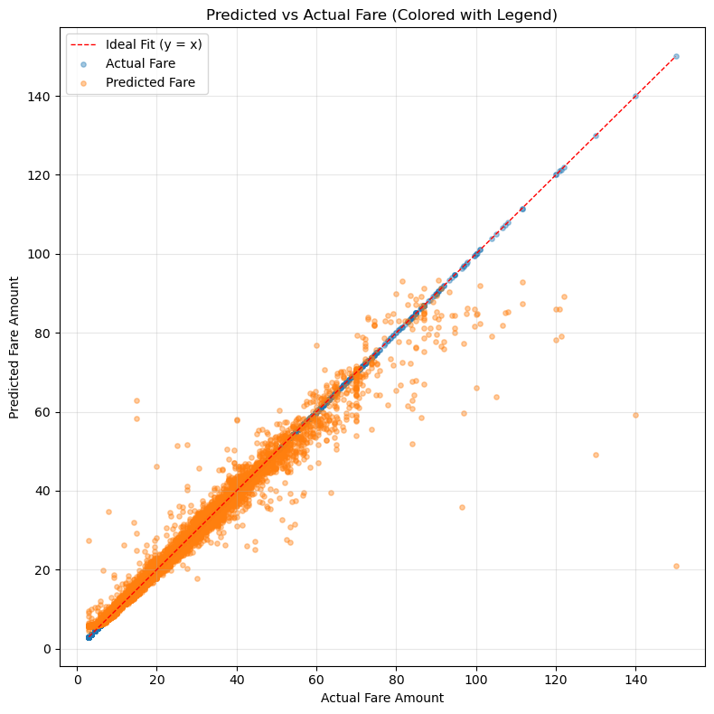

```python
pdf = (
    pred_df
    .select(["fare_amount", "prediction"])
    .sample(False, 0.001)
).toPandas()

y_actual = pdf["fare_amount"].values
y_pred   = pdf["prediction"].values

plt.figure(figsize=(8, 8))

plt.scatter(
    y_actual,
    y_actual,
    alpha=0.4,
    s=15,
    label="Actual Fare",
)

plt.scatter(
    y_actual,
    y_pred,
    alpha=0.4,
    s=15,
    label="Predicted Fare",
)

min_fare = min(y_actual.min(), y_pred.min())
max_fare = max(y_actual.max(), y_pred.max())
plt.plot(
    [min_fare, max_fare],
    [min_fare, max_fare],
    "r--",
    linewidth=1,
    label="Ideal Fit (y = x)",
)

plt.xlabel("Actual Fare Amount")
plt.ylabel("Predicted Fare Amount")
plt.title("Predicted vs Actual Fare (Colored with Legend)")
plt.legend()
plt.grid(alpha=0.3)

plt.tight_layout()
plt.show()
```

This plot shows the relationship between the model’s predictions and the true fare amounts. A good regression model should produce points that lie close to the diagonal reference line (y = x). In this case, most orange points fall near the line, especially for lower to mid-range fares (0–70), indicating that the model captures the general fare pattern reasonably well. However, as fares increase above ~70, the predictions start to deviate more visibly from the diagonal, suggesting higher variance and reduced accuracy for expensive trips. This pattern is common in taxi fare models because long-distance or airport trips tend to be more variable and harder to predict.

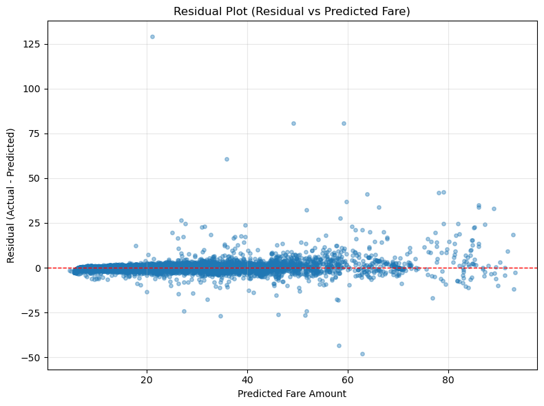

```python
residuals = y_actual - y_pred

plt.figure(figsize=(8, 6))

plt.scatter(y_pred, residuals, alpha=0.4, s=15)
plt.axhline(0, color="red", linestyle="--", linewidth=1)

plt.xlabel("Predicted Fare Amount")
plt.ylabel("Residual (Actual - Predicted)")
plt.title("Residual Plot (Residual vs Predicted Fare)")
plt.grid(alpha=0.3)

plt.tight_layout()
plt.show()
```

Residuals appear centered around zero for most predictions, which indicates that the model does not suffer from a strong systematic bias (i.e., it does not consistently over- or under-predict across the entire range). However, the spread of residuals increases as predicted fare increases, forming a mild “funnel shape.” This suggests heteroscedasticity, meaning prediction errors grow as the fare amount increases. This is typical for fare prediction since high-fare trips (often long-distance or airport rides) naturally have more variability. The presence of both positive and negative residual spikes also points to occasional large under- and over-predictions.

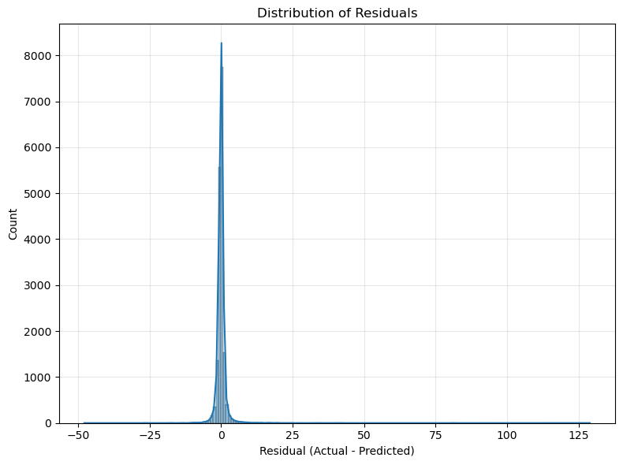

```python
import seaborn as sns

plt.figure(figsize=(8, 6))

sns.histplot(residuals, bins=200, kde=True)
# plt.axvline(0, color="red", linestyle="--", linewidth=1)

plt.xlabel("Residual (Actual - Predicted)")
plt.title("Distribution of Residuals")
plt.grid(alpha=0.3)

plt.tight_layout()
plt.show()
```

The residual distribution is sharply peaked around zero with long, thin tails on both sides. This indicates that the model predicts most trips fairly accurately, with small errors concentrated near zero. The tails, however, show that the model occasionally makes large errors for a small number of trips. The slight skewness to the right suggests the model slightly under-predicts fares more often than it over-predicts them, though not severely. Overall, the distribution is reasonably centered but clearly non-Gaussian, which is common for tree-based regression models.

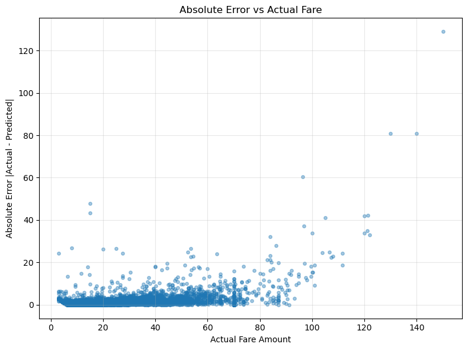

```python
abs_errors = abs(residuals)

plt.figure(figsize=(8, 6))

plt.scatter(y_actual, abs_errors, alpha=0.4, s=15)
plt.xlabel("Actual Fare Amount")
plt.ylabel("Absolute Error |Actual - Predicted|")
plt.title("Absolute Error vs Actual Fare")
plt.grid(alpha=0.3)

plt.tight_layout()
plt.show()
```

This plot shows that absolute error increases as the true fare amount increases. For low fares (0–30), errors are generally small and tightly clustered. As fares rise beyond 50 and especially above 80, the errors become larger and more dispersed. This confirms that the model performs best for short and medium trips, but struggles more with long or high-priced trips. This pattern is expected because Random Forests rely on averaging across trees, and extreme fare values often fall in less frequent parts of the feature space, reducing prediction precision. For business or operational use, this suggests targeted model adjustments or feature engineering for long trips.

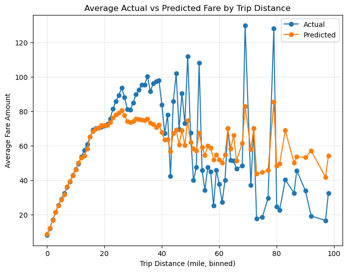

```python
from pyspark.sql.functions import col, floor
pdf = (
    pred_df
    .withColumn("trip_distance_bin", floor(col("trip_distance")))  # 1-mile bins
    .groupBy("trip_distance_bin")
    .agg(
        F.avg("fare_amount").alias("avg_actual_fare"),
        F.avg("prediction").alias("avg_pred_fare"),
        F.count("*").alias("n_trips")
    )
    .orderBy("trip_distance_bin")
).toPandas()

plt.figure(figsize=(8, 6))
plt.plot(pdf["trip_distance_bin"], pdf["avg_actual_fare"],
         marker="o", label="Actual")
plt.plot(pdf["trip_distance_bin"], pdf["avg_pred_fare"],
         marker="o", label="Predicted")

plt.xlabel("Trip Distance (mile, binned)")
plt.ylabel("Average Fare Amount")
plt.title("Average Actual vs Predicted Fare by Trip Distance")
plt.legend()
plt.grid(alpha=0.3)
plt.show()
```

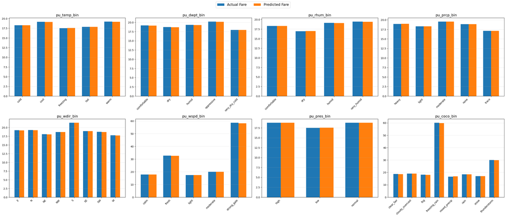

```python
import numpy as np

pu_weather = ["pu_temp_bin", "pu_dwpt_bin",
              "pu_rhum_bin", "pu_prcp_bin",
              "pu_wdir_bin", "pu_wspd_bin",
              "pu_pres_bin", "pu_coco_bin"]

fig, axes = plt.subplots(len(pu_weather) // 4, 4, figsize=(28, 12))
axes = axes.flatten()

pred_df = pred_df.withColumn(
    "residual", F.col("fare_amount") - F.col("prediction")
)

for i, weather in enumerate(pu_weather):
    ax = axes[i]

    pdf = (
        pred_df
        .groupBy(weather)
        .agg(
            F.avg("fare_amount").alias("avg_actual_fare"),
            F.avg("prediction").alias("avg_pred_fare"),
            F.count("*").alias("n_trips")
        )
        .orderBy(weather)
    ).toPandas()

    x = np.arange(len(pdf))
    width = 0.35

    ax.bar(x - width/2, pdf["avg_actual_fare"], width, label="Actual Fare")
    ax.bar(x + width/2, pdf["avg_pred_fare"], width, label="Predicted Fare")

    ax.set_xticks(x)
    ax.set_xticklabels(pdf[weather], rotation=45, ha="right")

    ax.set_title(f"{weather}", fontsize=14)
    ax.grid(axis="y", alpha=0.3)

handles, labels = axes[0].get_legend_handles_labels()
fig.legend(handles, labels, loc="upper center", ncol=2, fontsize=14)

plt.tight_layout(rect=[0, 0, 1, 0.95])
plt.show()
```

Across all eight weather-related features, the predicted average fares closely track the actual averages, indicating that the model successfully incorporates weather information without introducing strong biases. Most weather bins show very small differences between actual and predicted values, suggesting that weather effects—temperature, humidity, precipitation, wind conditions, pressure, and general weather category—do not significantly distort the model’s fare estimation.